# Evidencia 2

- Preparación
  - Librerías
  - Utilidades
- Metodología
  - Video
  - Caso seleccionado
  - Longitud de las secuencias
  - Comparación de las secuencias
  - Árbol filogenético
    - Matriz de distancia
    - Árboles
  - Árbol filogenético por continentes
  - Resultado final
  - Conclusión
- Referencias

Análisis de biología computacional `BT1013.525`

```
Víctor Manuel Puga Ruiz     A01568636
```

# Preparación

## Librerías

```r
suppressMessages(library(seqinr))
suppressMessages(library(ape))
suppressMessages(library(ggplot2))
suppressMessages(library(ggtree))
```

## Utilidades

```r
seq.length <- function(dna.seq) {
  getLength(dna.seq)
}

seq.composition <- function(dna.seq) {
  total <- seq.length(dna.seq)
  bases <- count(dna.seq, 1)
  bases["n"] <- total - sum(bases)

  sapply(bases, function(x) {
    round(x / total * 100, 2)
  })
}

base.colors <- c(
  "-" = "#FD8D0E",
  "t" = "#106BFF",
  "a" = "#FC2B2D",
  "g" = "#30D33B",
  "c" = "#FECF0F",
  "n" = "#3D3D3D",

  "T" = "#106BFF",
  "A" = "#FC2B2D",
  "G" = "#30D33B",
  "C" = "#FECF0F",
  "N" = "#3D3D3D"
)

title.theme <- theme(
  plot.title = element_text(size = 30, face = "bold", hjust = 0.5),
  plot.subtitle = element_text(size = 20, hjust = 0.5),
  plot.caption =  element_text(size = 10)
)

legend.theme <- theme(
  legend.title =  element_text(size = 25),
  legend.key.size = unit(1, "cm"),
  legend.text = element_text(size = 20)
)

caption <- labs(caption = "Data source: NCBI")
```

# Metodología

## Video

[video not shown]

## Caso seleccionado

La investigación que se vamos a realizar es sobre las variantes del virus en los países con mayor cantidad de casos. Al finalizar el estudio, se busca determinar qué tan diferentes son las variantes entre estos países.

También se demostrará si hay diferencias significativas en el virus entre las poblaciones Asiáticas, Hispanas, Europeas, y Africanas, o si son similares.

Muestras de los primeros 20 países con mayor número de casos (descendiente, April 26, 2021 at 3:45 p.m. ET)

```r
accessions <- c(
  "MZ021779.1" = "USA",
  "MW828655.1" = "India",
  "MW592707.1" = "Brazil",
  "HG993789.1" = "France",
  "MW305251.1" = "Russia",
  "MW320691.1" = "Turkey",
  "OD906787.1" = "United Kingdom",
  "MW854297.1" = "Italy",
  "MW976780.1" = "Spain",
  "MW633324.1" = "Germany",
  "MW633898.1" = "Argentina",
  "MT470219.1" = "Colombia",
  "HG994166.1" = "Poland",
  "MW737421.1" = "Iran",
  "MW595909.1" = "Mexico",
  ##""         = "Ukraine",
  "MT263074.1" = "Peru",
  "MZ026854.1" = "Indonesia",
  "MT517423.1" = "Czech Republic",
  "MW981442.1" = "South Africa",
  "MW309426.1" = "Canada"
)

contintents <- c(
  "MZ021779.1" = "North America",
  "MW828655.1" = "Asia",
  "MW592707.1" = "South America",
  "HG993789.1" = "Europe",
  "MW305251.1" = "Europe",
  "MW320691.1" = "Asia",
  "OD906787.1" = "Europe",
  "MW854297.1" = "Europe",
  "MW976780.1" = "Europe",
  "MW633324.1" = "Europe",
  "MW633898.1" = "South America",
  "MT470219.1" = "South America",
  "HG994166.1" = "Europe",
  "MW737421.1" = "Asia",
  "MW595909.1" = "North America",
  "MT263074.1" = "South America",
  "MZ026854.1" = "Asia",
  "MT517423.1" = "Europe",
  "MW981442.1" = "Africa",
  "MW309426.1" = "North America"
)
```

```r
if (!file.exists("./data/MERGED.fasta")) { ## only search once
  sequences <- read.GenBank(names(accessions))
  write.dna(sequences, file = "./data/MERGED.fasta", colsep = "", format = "fasta")
}
```

## Longitud de las secuencias

```r
all.seq <- read.fasta("./data/MERGED.fasta")
all.seq.bin <- read.dna("./data/MERGED.fasta", format = "fasta")
all.seq.bin
```

```
## 20 DNA sequences in binary format stored in a list.
##
## Mean sequence length: 29833.8
##    Shortest sequence: 29717
##     Longest sequence: 29903
##
## Labels:
## MZ021779.1
## MW828655.1
## MW592707.1
## HG993789.1
## MW305251.1
## MW320691.1
## ...
##
## Base composition:
##     a     c     g     t
## 0.299 0.184 0.196 0.321
## (Total: 596.68 kb)
```

```r
lengths <- data.frame(Accession = character(), Country = character(), Length = integer())

for (i in 1:length(all.seq)) {
  ac <- labels(all.seq)[i]
  lengths[i, ] <- list(ac, accessions[ac],  seq.length(all.seq[[ac]]))
}

lengths
```

```
##     Accession        Country Length
## 1  MZ021779.1            USA  29739
## 2  MW828655.1          India  29903
## 3  MW592707.1         Brazil  29862
## 4  HG993789.1         France  29885
## 5  MW305251.1         Russia  29841
## 6  MW320691.1         Turkey  29813
## 7  OD906787.1 United Kingdom  29903
## 8  MW854297.1          Italy  29849
## 9  MW976780.1          Spain  29763
## 10 MW633324.1        Germany  29779
## 11 MW633898.1      Argentina  29717
## 12 MT470219.1       Colombia  29903
## 13 HG994166.1         Poland  29903
## 14 MW737421.1           Iran  29816
## 15 MW595909.1         Mexico  29866
## 16 MT263074.1           Peru  29856
## 17 MZ026854.1      Indonesia  29782
## 18 MT517423.1 Czech Republic  29866
## 19 MW981442.1   South Africa  29848
## 20 MW309426.1         Canada  29782
```

Todas las secuencias tienen una longitud de alrededor de 29800 bases. Estas variaciones de longitudes se pueden deber a los cambios que hay en el genoma por mutaciones, o simplemente por la probabilidad de que ocurran errores al medir.

## Comparación de las secuencias

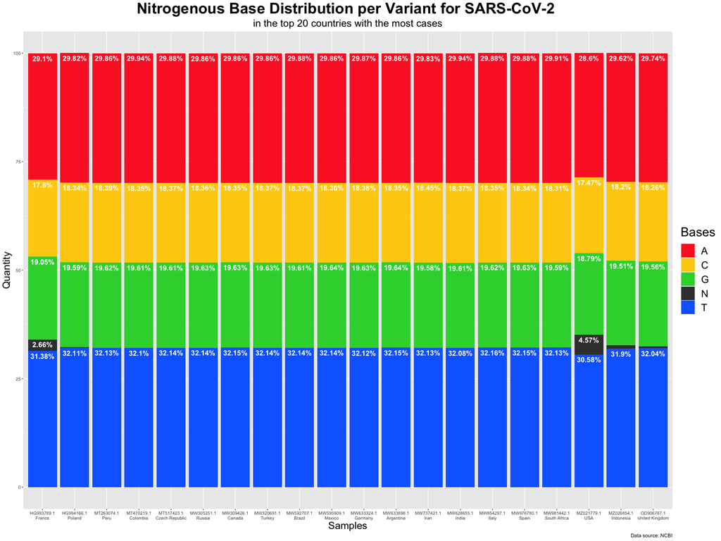

```r
data <- data.frame(Variant = character(), Base = character(), Value = integer())

n <- 0
for (i in labels(all.seq)) {
  var.name <- paste(i, accessions[i], sep = "\n")
  comps <- seq.composition(all.seq[[i]])
  data[n + 1,] <- list(Variant = var.name, Base = "A", Value = comps["a"])
  data[n + 2,] <- list(Variant = var.name, Base = "T", Value = comps["t"])
  data[n + 3,] <- list(Variant = var.name, Base = "G", Value = comps["g"])
  data[n + 4,] <- list(Variant = var.name, Base = "C", Value = comps["c"])
  data[n + 5,] <- list(Variant = var.name, Base = "N", Value = comps["n"])
  n <- n + 5
}

data.labs <- sapply(data$Value, function(v) { paste(v, "%", sep = "") })

ggplot(data, aes(fill = Base, y = Value, x = Variant)) +
    geom_bar(position = "stack", stat = "identity") +
    scale_fill_manual(values = base.colors) +
    geom_text(
      aes(label = data.labs),
      position = position_stack(),
      vjust = 1.5,
      colour = "white",
      fontface = "bold",
      check_overlap = TRUE,
      size = 5
    ) +
    labs(
      title = "Nitrogenous Base Distribution per Variant for SARS-CoV-2 ",
      subtitle = "in the top 20 countries with the most cases",
      x = "Samples",
      y = "Quantity",
      fill = "Bases"
    ) + caption +
    theme(axis.title = element_text(size = 20)) + title.theme + legend.theme
```

Con esta gráfica de las distribuciones se puede observar que, al menos en su composición porcentual de bases nitrogenadas, las muestras se podrían dividir en 2 categorías. Las muestras de Estados Unidos y Francia tienen una composición similar. Las muestras de los otros 18 países también se parecen entre sí. La única diferencia significativa entre estos dos grupos es la cantidad de bases que no pudieron ser identificadas, marcadas como `N`.

## Árbol filogenético

La alineación de las secuencias se realizó con Clustal Omega en https://www.ebi.ac.uk/Tools/msa/clustalo/. Este paso es un requerimiento para encontrar la matriz de distancia entre las secuencias, pues cada una debe tener la misma longitud.

El proceso que se efectúa al alinear las secuencias es buscar las secciones que se repiten en la mayoría de las secuencias, alinearlas, y rellenar los espacios vacíos con guiones (`-`).

Por ejemplo, la alineación de las primeras bases de las 20 secuencias se visualiza a continuación.

```
CLUSTAL O(1.2.4) multiple sequence alignment


MZ021779.1      ------------------------------------------------------agatct    6
HG993789.1      nnnnnnnnnnnnnnnnnnnnnnnnnnnnnnnnnnnnnnactttcgatctcttgtagatct    60
MZ026854.1      ------------------------------------------------------agatct    6
MW854297.1      -------gtttataccttcccaggtaacaaaccaaccaactttcgatctcttgtagatct    53
MW976780.1      ------------------------------------------------------agatct    6
MW981442.1      -------------------------------------aactttcgatctcttgtagatct    23
MW737421.1      --------------------------------------actttcgatctcttgtagatct    22
OD906787.1      nnnnnnnnnnnnnnnnnnnnnnnnnnnnnnnnnnnnnnnnnnnnnnnnnnnnnnagatct    60
MW595909.1      ------ggtttataccttcccaggtaacaaaccaaccaactttcgatctcttgtagatct    54
MW633324.1      ------------------------------------------------------agatct    6
MW633898.1      ------------------------------------------------------------    0
MW828655.1      attaaaggtttataccttcccaggtaacaaaccaaccaactttcgatctcttgtagatct    60
MW305251.1      ---------------------------------aaccaactttcgatctcttgtagatct    27
MT470219.1      attaaaggtttataccttcccaggtaacaaaccaaccaactttcgatctcttgtagatct    60
HG994166.1      nnnnnnggtttataccttgccaggtaacaaaccaaccaactttcgatctcttgtagatct    60
MW592707.1      ------------taccttcccaggtaacaaaccaaccaactttcgatctcttgtagatct    48
MW309426.1      ------------------------------------------------------agatct    6
MT517423.1      ----------tataccttcccaggtaacaaaccaaccaactttcgatctcttgtagatct    50
MW320691.1      --------------------------------caaccaactttcgatctcttgtagatct    28
MT263074.1      ---------ttataccttcccaggtaacaaaccaaccaactttcgatctcttgtagatct    51


MZ021779.1      gttctctaaacgaactttaaaatctgtgtggctgtcactcggctgcatgcttagtgcact    66
HG993789.1      gttctctaaacgaactttaaaatctgtgtggctgtcactcggctgcatgcttagtgcact    120
MZ026854.1      gttctctaaacgaactttaaaatctgtgtggctgtcactcggctgcatgcttagtgcact    66
MW854297.1      gttctctaaacgaactttaaaatctgtgtggctgtcactcggctgcatgcttagtgcact    113
MW976780.1      gttctctaaacgaactttaaaatctgtgtggctgtcactcggctgcatgcttagtgcact    66
MW981442.1      gttctctaaacgaactttaaaatctgtgtggctgtcactcggctgcatgcttagtgcact    83
MW737421.1      gttctctaaacgaactttaaaatctgtgtggctgtcactcggctgcatgcttagtgcact    82
OD906787.1      gttctctaaacgaactttaaaatctgtgtggctgtcactcggctgcatgcttagtgcact    120
MW595909.1      gttctctaaacgaactttaaaatctgtgtggctgtcactcggctgcatgcttagtgcact    114
MW633324.1      gttctctaaacgaactttaaaatctgtgtggctgtcactcggctgcatgcttagtgcact    66
MW633898.1      ----tctaaacgaactttaaaatctgtgtggctgtcactcggctgcatgcttagtgcact    56
MW828655.1      gttctctaaacgaactttaaaatctgtgtggctgtcactcggctgcatgcttagtgcact    120
MW305251.1      gttctctaaacgaactttaaaatctgtgtggctgtcactcggctgcatgcttagtgcact    87
MT470219.1      gttctctaaacgaactttaaaatctgtgtggctgtcactcggctgcatgcttagtgcact    120
HG994166.1      gttctctaaacgaactttaaaatctgtgtggctgtcactcggctgcatgcttagtgcact    120
MW592707.1      gttctctaaacgaactttaaaatctgtgtggctgtcactcggctgcatgcttagtgcact    108
MW309426.1      gttctctaaacgaactttaaaatctgtgtggctgtcactcggctgcatgcttagtgcact    66
MT517423.1      gttctctaaacgaactttaaaatctgtgtggctgtcactcggctgcatgcttagtgcact    110
MW320691.1      gttctctaaacgaactttaaaatctgtgtggctgtcactcggctgcatgcttagtgcact    88
MT263074.1      gttctctaaacgaactttaaaatctgtgtggctgtcactcggctgcatgcttagtgcact    111
                    ********************************************************

                                      ...
```

```r
clust <- read.alignment(
  "./data/clustalo-I20210427-013920-0382-41949213-p2m.clustal_num",
  format = "clustal", forceToLower = TRUE,
)
dna <- as.DNAbin(clust)
dna
```

```
## 20 DNA sequences in binary format stored in a matrix.
##
## All sequences of same length: 30406
##
## Labels:
## MZ021779.1
## HG993789.1
## MZ026854.1
## MW854297.1
## MW976780.1
## MW981442.1
## ...
##
## Base composition:
##     a     c     g     t
## 0.299 0.184 0.196 0.321
## (Total: 608.12 kb)
```

### Matriz de distancia

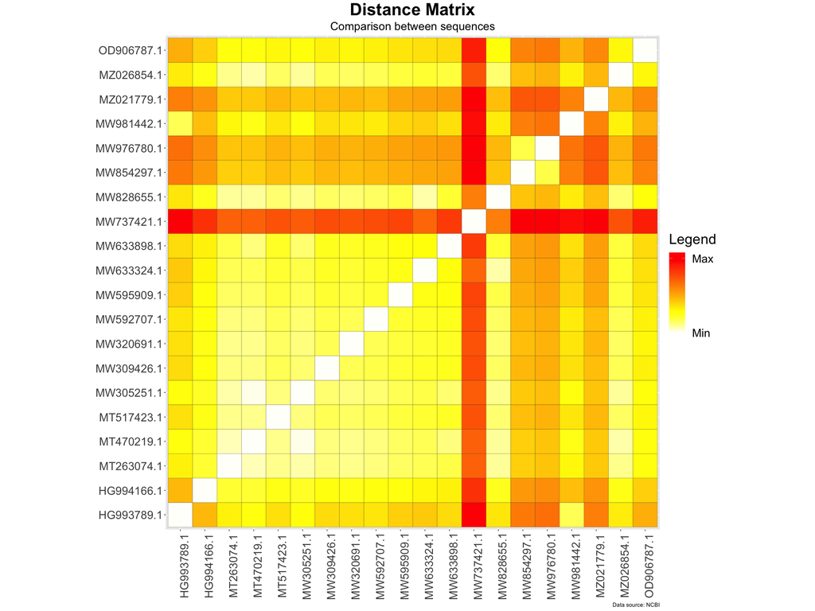

```r
D <- dist.dna(dna)
D.mat <- as.matrix(D)

heat.mat <- data.frame(X = character(), Y = character(), Val = double())

n <- 0
for (col in colnames(D.mat)) {
  for (r in rownames(D.mat)) {
    n <- n + 1
    heat.mat[n, ] <- list(col, r, D.mat[col, r])
  }
}

ggplot(heat.mat, aes(X, Y, fill = Val)) +
  geom_tile(color = "black") +
  coord_fixed() +
  scale_fill_gradientn(
    colours = heat.colors(100, rev = TRUE),
    n.breaks = 2,
    labels = c("Min", "Max"),
  ) +
  labs(
      title = "Distance Matrix",
      subtitle = "Comparison between sequences",
      fill = "Legend",
      x = NULL,
      y = NULL
  ) + caption +
  theme(
    axis.text.x = element_text(size = 20, angle = 90),
    axis.text.y = element_text(size = 20)
  ) + title.theme + legend.theme
```

Las áreas de amarillo claro significan que hay poca diferencia, mientras que los rojos oscuros significan mayor diferencia entre secuencias. Se aprecia una diagonal, que es la comparación de las secuencias con ellas mismas. Como se espera, la distancia entre ellas es nula.Visualizando este resultado, se pudiera inferir que la secuencia `MW737421.1`, de Irán, estará más alejada de las demás en el árbol filogenético.

### Árboles

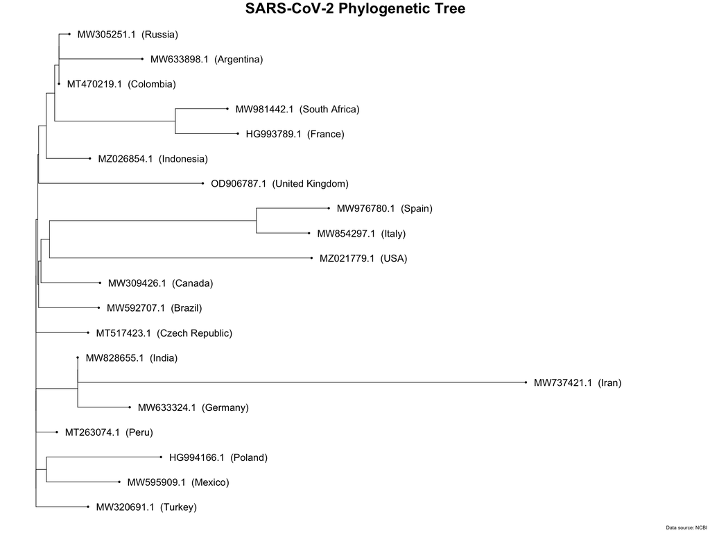

```r
tree <- nj(D)

ggtree(tree) +
  xlim(0, 0.0022) +
  geom_tippoint() +
  geom_tiplab(
    aes(label = paste(label, "  (", accessions[label], ")", sep = "")),
    offset = 0.00002,
    size = 7
  ) +
  labs(title = "SARS-CoV-2 Phylogenetic Tree") + caption + title.theme
```

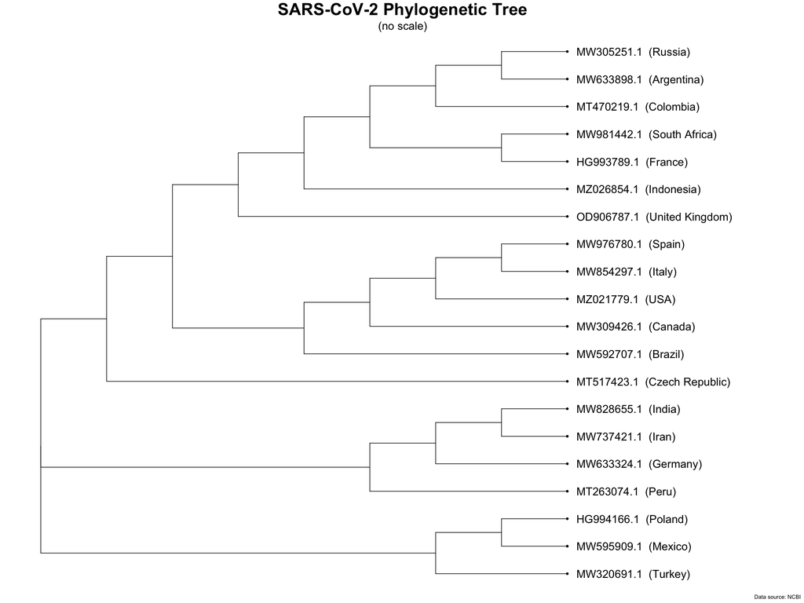

```r
ggtree(tree, branch.length = "none") +
  xlim(0, 11) +
  geom_tippoint() +
  geom_tiplab(
    aes(label = paste(label, "  (", accessions[label], ")", sep = "")),
    offset = 0.1,
    size = 7
  ) +
  labs(
    title = "SARS-CoV-2 Phylogenetic Tree",
    subtitle = "(no scale)"
  ) + caption + title.theme
```

## Árbol filogenético por continentes

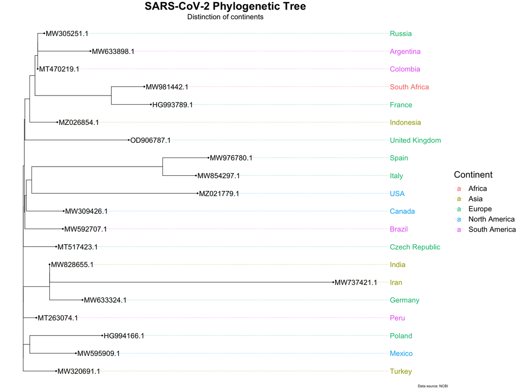

```r
ggtree(tree) +
  xlim(0, 0.0022) +
  geom_tippoint() +
  geom_tiplab(
    aes(label = accessions[label], color = contintents[label]),
    offset = 0.0003,
    align = TRUE,
    size = 7
  ) +
  geom_tiplab(size = 7) +
  labs(
    title = "SARS-CoV-2 Phylogenetic Tree",
    subtitle = "Distinction of continents",
    color = "Continent"
  ) + caption + title.theme + legend.theme
```

## Resultado final

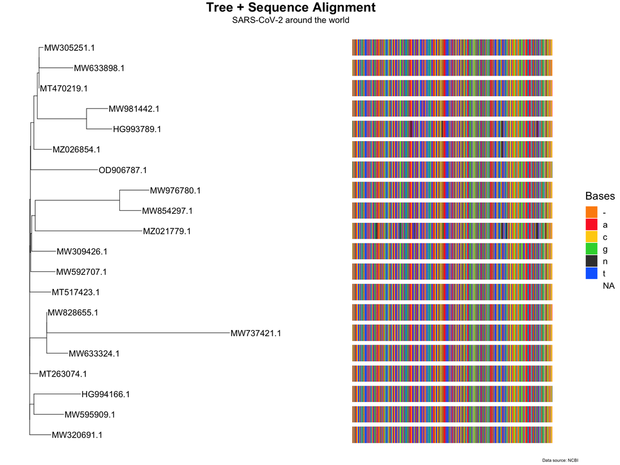

```r
msaplot(p = ggtree(tree), fasta = dna, color = base.colors, offset = 0.001) +
  geom_tiplab(size = 7) +
  labs(
    title = "Tree + Sequence Alignment",
    subtitle = "SARS-CoV-2 around the world",
    fill = "Bases"
  ) + caption + title.theme + legend.theme
```

## Conclusión

Visualizando los resultados del análisis, se encuentra que, al menos para las muestras que fueron seleccionadas, **no hay una correlación grande entre la variante del virus y su localización geográfica**, pues en el árbol filogenético los países están mezclados entre ramas.

Aún así, las secuencias que se tomaron para cada país no son una muestra representativa, pues sólo es una por país, y fueron elegidas de manera aleatoria. Se podría hacer un análisis complementario que tomara en cuenta más muestras del virus, para comparar la distribución de los nodos con las variantes del virus y así encontrar con mayor certeza si las variantes del SARS-CoV-2 que se encuentran en los diferentes continentes son en realidad la misma variante o una diferente.

# Referencias

- *Severe acute respiratory syndrome coronavirus 2 data hub*. Recuperado el 26 de abril del 2021, de https://www.ncbi.nlm.nih.gov/labs/virus/vssi/#/virus?SeqType_s=Nucleotide&VirusLineage_ss=Severe%20acute%20respiratory%20syndrome%20coronavirus%202,%20taxid:2697049
- *Tracking Covid-19’s global spread*. Recuperado el 26 de abril del 2021, de https://edition.cnn.com/interactive/2020/health/coronavirus-maps-and-cases/